# STA 138 Final Project

# Conclusion

Beginning from the model that best fits the data from above, we can look at the summary of the model. This summary of the model would suggest that Workspace 1, Employment >=10 and SmokingYes all have positive and statistically significant effects on the chance of contracting byssinosis. Using the Wald tests and the confidence intervals of the odds ratios for the variables, we see that all of these variables have statistically significant effects on the chance of contracting byssinosis. Because Workspace 1, the most dusty workplace, is among these statistically significant variables with a positive effect on the chance of contracting byssinosis, we conclude that Workplace dustiness positively contributes to the chance of byssinosis.

```
## $Employment
## [1] "<10"   "10-19" ">=20"
##
## $Smoking
## [1] "Yes" "No"
##
## $Sex
## [1] "M" "F"
##
## $Race
## [1] "W" "O"
##
## $Workspace
## [1] 1 2 3
## Levels: 3 2 1
```

```
##
## Call:
## glm(formula = cbind(Byssinosis, Non.Byssinosis) ~ Employment +
##     Smoking + Sex + Race + Workspace, family = binomial(), data = byss)
##
## Deviance Residuals:
##     Min       1Q   Median       3Q      Max
## -1.5076  -0.8218  -0.2693   0.2879   1.5709
##
## Coefficients:
##                 Estimate Std. Error z value Pr(>|z|)
## (Intercept)      -5.1028     0.2643 -19.308  < 2e-16 ***
## Employment>=20    0.7444     0.2169   3.432 0.000600 ***
## Employment10-19   0.5678     0.2619   2.168 0.030177 *
## SmokingYes        0.6709     0.1961   3.421 0.000625 ***
## SexM             -0.1503     0.2296  -0.655 0.512777
## RaceW            -0.1176     0.2077  -0.566 0.571270
## Workspace2        0.1713     0.2870   0.597 0.550546
## Workspace1        2.7617     0.2172  12.713  < 2e-16 ***
## ---
## Signif. codes:  0 '***' 0.001 '**' 0.01 '*' 0.05 '.' 0.1 ' ' 1
##
## (Dispersion parameter for binomial family taken to be 1)
##
##     Null deviance: 324.114  on 64  degrees of freedom
## Residual deviance:  42.679  on 57  degrees of freedom
## AIC: 164.98
##
## Number of Fisher Scoring iterations: 5
```

```
## [1] 182.3771
```

```
##                       2.5 %     97.5 %
## (Intercept)     -5.62081192 -4.5848382
## Employment>=20   0.31923027  1.1695809
## Employment10-19  0.05443102  1.0812555
## SmokingYes       0.28650604  1.0553657
## SexM            -0.60034204  0.2997582
## RaceW           -0.52467718  0.2894865
## Workspace2      -0.39121682  0.7338872
## Workspace1       2.33596023  3.1874919
```

```
##
## Call:
## glm(formula = cbind(Byssinosis, Non.Byssinosis) ~ Workspace +
##     Smoking + Employment, family = binomial(), data = byss)
##
## Deviance Residuals:
##     Min       1Q   Median       3Q      Max
## -1.6131  -0.8065  -0.2514   0.3084   1.6743
##
## Coefficients:
##                 Estimate Std. Error z value Pr(>|z|)
## (Intercept)      -5.2077     0.2375 -21.931  < 2e-16 ***
## Workspace2        0.1925     0.2852   0.675 0.499666
## Workspace1        2.7393     0.1914  14.315  < 2e-16 ***
## SmokingYes        0.6464     0.1925   3.358 0.000786 ***
## Employment>=20    0.6596     0.1820   3.625 0.000289 ***
## Employment10-19   0.5055     0.2492   2.029 0.042508 *
## ---
## Signif. codes:  0 '***' 0.001 '**' 0.01 '*' 0.05 '.' 0.1 ' ' 1
##
## (Dispersion parameter for binomial family taken to be 1)
##
##     Null deviance: 324.114  on 64  degrees of freedom
## Residual deviance:  43.429  on 59  degrees of freedom
## AIC: 161.73
##
## Number of Fisher Scoring iterations: 5
```

```
## [1] 174.779
```

```
##                       2.5 %     97.5 %
## (Intercept)     -5.67315243 -4.7423365
## Workspace2      -0.36641854  0.7513960
## Workspace1       2.36420684  3.1143267
## SmokingYes       0.26909047  1.0236948
## Employment>=20   0.30292282  1.0161852
## Employment10-19  0.01708115  0.9938192
```

```
##
## Call:
## glm(formula = cbind(Byssinosis, Non.Byssinosis) ~ Workspace,
##     family = binomial, data = byss)
##
## Deviance Residuals:
##     Min       1Q   Median       3Q      Max
## -2.3374  -0.9329  -0.2774   0.2242   3.4086
##
## Coefficients:
##             Estimate Std. Error z value Pr(>|z|)
## (Intercept)  -4.4200     0.1571 -28.133   <2e-16 ***
## Workspace2    0.1542     0.2846   0.542    0.588
## Workspace1    2.7389     0.1897  14.439   <2e-16 ***
## ---
## Signif. codes:  0 '***' 0.001 '**' 0.01 '*' 0.05 '.' 0.1 ' ' 1
##
## (Dispersion parameter for binomial family taken to be 1)
##
##     Null deviance: 324.114  on 64  degrees of freedom
## Residual deviance:  70.192  on 62  degrees of freedom
## AIC: 182.5
##
## Number of Fisher Scoring iterations: 5
```

```
##
## Call:
## glm(formula = cbind(Byssinosis, Non.Byssinosis) ~ Workspace +
##     Smoking + Employment, family = binomial(), data = byss2)
##
## Deviance Residuals:
##     Min       1Q   Median       3Q      Max
## -1.6156  -0.7821  -0.2584   0.3073   1.8354
##
## Coefficients:
##                 Estimate Std. Error z value Pr(>|z|)
## (Intercept)      -5.1495     0.2190 -23.516  < 2e-16 ***
## Workspace1        2.6842     0.1704  15.749  < 2e-16 ***
## SmokingYes        0.6445     0.1925   3.349 0.000812 ***
## Employment>=20    0.6571     0.1819   3.612 0.000304 ***
## Employment10-19   0.5007     0.2490   2.011 0.044352 *
## ---
## Signif. codes:  0 '***' 0.001 '**' 0.01 '*' 0.05 '.' 0.1 ' ' 1
##
## (Dispersion parameter for binomial family taken to be 1)
##
##     Null deviance: 324.114  on 64  degrees of freedom
## Residual deviance:  43.874  on 60  degrees of freedom
## AIC: 160.18
##
## Number of Fisher Scoring iterations: 5
```

```
## [1] 171.0489
```

```
##                       2.5 %     97.5 %
## (Intercept)     -5.57871322 -4.7203201
## Workspace1       2.35019087  3.0182868
## SmokingYes       0.26727387  1.0217511
## Employment>=20   0.30050913  1.0136781
## Employment10-19  0.01264627  0.9888278
```

```
##
## Call:
## glm(formula = cbind(Byssinosis, Non.Byssinosis) ~ Workspace +
##     Employment + Smoking, family = binomial(), data = byss2)
##
## Deviance Residuals:
##     Min       1Q   Median       3Q      Max
## -1.7071  -0.8030  -0.2876   0.3195   1.8273
##
## Coefficients:
##                Estimate Std. Error z value Pr(>|z|)
## (Intercept)     -5.1427     0.2185 -23.538  < 2e-16 ***
## Workspace1       2.6829     0.1704  15.746  < 2e-16 ***
## Employment>=10   0.6148     0.1704   3.607  0.00031 ***
## SmokingYes       0.6364     0.1920   3.314  0.00092 ***
## ---
## Signif. codes:  0 '***' 0.001 '**' 0.01 '*' 0.05 '.' 0.1 ' ' 1
##
## (Dispersion parameter for binomial family taken to be 1)
##
##     Null deviance: 324.114  on 64  degrees of freedom
## Residual deviance:  44.288  on 61  degrees of freedom
## AIC: 158.59
##
## Number of Fisher Scoring iterations: 5
```

```
## [1] 167.289
```

```
##                     2.5 %     97.5 %
## (Intercept)    -5.5708797 -4.7144360
## Workspace1      2.3489479  3.0168555
## Employment>=10  0.2807494  0.9488551
## SmokingYes      0.2600059  1.0128046
```

```
## [1] 0.6870723
```

```
## [1] 0.5050566
```

```
## [1] 0.650914
```

```
## [1] 0.5197143
```

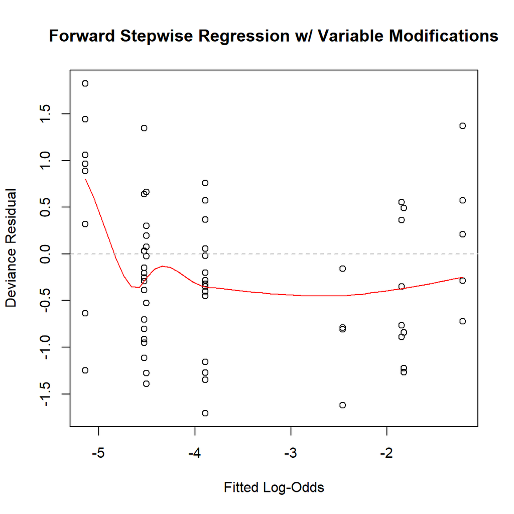

```r
knitr::opts_chunk$set(echo = TRUE)
byss = read.csv("./Dataset/Byssinosis.csv")
# change Workspace to factor
byss$Workspace = factor(byss$Workspace, levels = c("3", "2", "1"))
# add Total column equal to Byssinosis + Non.Byssinosis
byss$Total = byss$Byssinosis + byss$Non.Byssinosis
# remove rows which have no total
byss = byss[byss$Total!=0,]
# unique values of each predictor variable
sapply(byss[1:5], function(x) unique(x))
glm1 = glm(cbind(Byssinosis, Non.Byssinosis)~Employment + Smoking + Sex + Race + Workspace,
           family=binomial(),
           data=byss)
summary(glm1)
BIC(glm1)
confint.default(glm1)
result1 = step(glm(cbind(Byssinosis, Non.Byssinosis)~1, binomial(), byss),
                  scope = ~Employment*Smoking*Sex*Race*Workspace,
                  k=log(72),
                  trace=0,
                  direction="forward")
summary(result1)
BIC(result1)
confint.default(result1)
glm2 = glm(cbind(Byssinosis, Non.Byssinosis)~Workspace, binomial, byss)
summary(glm2)
# changing Workplace var
# 2 & 3 -> 3 (less dusty)
# 1 -> 1 (more dusty)
byss2 = byss
byss2$Workspace[byss2$Workspace == 2] = 3
new1 = step(glm(cbind(Byssinosis, Non.Byssinosis)~1, binomial(), byss2),
                  scope = ~Employment*Smoking*Sex*Race*Workspace,
                  k=log(72),
                  trace=0,
                  direction="forward")
summary(new1)
BIC(new1)
confint.default(new1)
# changing Employment var
# 10-19 & >=20 -> >=10
byss2$Employment[byss2$Employment == "10-19" | byss2$Employment == ">=20"] = ">=10"
# new stepwise w/ Employment modification
new2 = step(glm(cbind(Byssinosis, Non.Byssinosis)~1, binomial(), byss2),
                  scope = ~Employment*Smoking*Sex*Race*Workspace,
                  k=log(72),
                  trace=0,
                  direction="forward")
summary(new2)
BIC(new2)
confint.default(new2)
# H_0: models are equivalent -> use simpler model
# H_1: models are not equivalent -> use more complex model
anv = anova(result1, glm1)
pvalue = 1-pchisq(anv[2, 4], anv[2,3])
pvalue
1-pchisq(anova(new1, result1)[2, 4], anova(new1, result1)[2,3]) # compare new1 & result1 w/ LRT
1-pchisq(anova(new2, result1)[2, 4], anova(new2, result1)[2,3]) # compare new2 & result1 w/ LRT
1-pchisq(anova(new2, new1)[2, 4], anova(new2, new1)[2,3]) # compare new2 & new1 w/ LRT
# new2
ry = residuals(new2, type="deviance")
rx = qlogis(fitted.values(new2))

plot(rx, ry,
     xlab = "Fitted Log-Odds",
     ylab = "Deviance Residual",
     main = "Forward Stepwise Regression w/ Variable Modifications",
     col = "black")
lines(loess.smooth(rx, ry), col="red")
abline(h=0, lty=2, col="grey")
```